# Covid 19 Data Analaysis

2023-06-25

###This report contains the data analysis and Visualization of following Analysis and Visualization of US totals Analysis and Visualization for State of Illinois cases vs deaths New case vs new deaths in the state of Alaska Lowest Deaths per cases Highest Deaths per cases Linear model relationship between cases per thousand to deaths per thousand

###Question of Interest ###How new cases related to deaths ###Which states are more prone to deaths and what is their background? ###What is the impact on Vaccination? Did deaths started to reduce after vaccination? ###Is population directly related to cases and deaths?

###SOURCE OF DATA

##This data is sourced on the basis of study conducted by Johns Hopkins University.This includes separate dataset for Global and another for US.

###US_cases

```
## # A tibble: 3,819,906 × 6
##    Admin2  Province_State Country_Region Combined_Key         date       cases
##    <chr>   <chr>          <chr>          <chr>                <date>     <dbl>
##  1 Autauga Alabama        US             Autauga, Alabama, US 2020-01-22     0
##  2 Autauga Alabama        US             Autauga, Alabama, US 2020-01-23     0
##  3 Autauga Alabama        US             Autauga, Alabama, US 2020-01-24     0
##  4 Autauga Alabama        US             Autauga, Alabama, US 2020-01-25     0
##  5 Autauga Alabama        US             Autauga, Alabama, US 2020-01-26     0
##  6 Autauga Alabama        US             Autauga, Alabama, US 2020-01-27     0
##  7 Autauga Alabama        US             Autauga, Alabama, US 2020-01-28     0
##  8 Autauga Alabama        US             Autauga, Alabama, US 2020-01-29     0
##  9 Autauga Alabama        US             Autauga, Alabama, US 2020-01-30     0
## 10 Autauga Alabama        US             Autauga, Alabama, US 2020-01-31     0
## # ℹ 3,819,896 more rows
```

###US_deaths

```
## # A tibble: 3,819,906 × 7
##    Admin2  Province_State Country_Region Combined_Key      Population date
##    <chr>   <chr>          <chr>          <chr>                  <dbl> <date>
##  1 Autauga Alabama        US             Autauga, Alabama…      55869 2020-01-22
##  2 Autauga Alabama        US             Autauga, Alabama…      55869 2020-01-23
##  3 Autauga Alabama        US             Autauga, Alabama…      55869 2020-01-24
##  4 Autauga Alabama        US             Autauga, Alabama…      55869 2020-01-25
##  5 Autauga Alabama        US             Autauga, Alabama…      55869 2020-01-26
##  6 Autauga Alabama        US             Autauga, Alabama…      55869 2020-01-27
##  7 Autauga Alabama        US             Autauga, Alabama…      55869 2020-01-28
##  8 Autauga Alabama        US             Autauga, Alabama…      55869 2020-01-29
##  9 Autauga Alabama        US             Autauga, Alabama…      55869 2020-01-30
## 10 Autauga Alabama        US             Autauga, Alabama…      55869 2020-01-31
## # ℹ 3,819,896 more rows
## # ℹ 1 more variable: deaths <dbl>
```

###US

```
## # A tibble: 3,819,906 × 8
##    Admin2 Province_State Country_Region Combined_Key date       cases Population
##    <chr>  <chr>          <chr>          <chr>        <date>     <dbl>      <dbl>
##  1 Autau… Alabama        US             Autauga, Al… 2020-01-22     0      55869
##  2 Autau… Alabama        US             Autauga, Al… 2020-01-23     0      55869
##  3 Autau… Alabama        US             Autauga, Al… 2020-01-24     0      55869
##  4 Autau… Alabama        US             Autauga, Al… 2020-01-25     0      55869
##  5 Autau… Alabama        US             Autauga, Al… 2020-01-26     0      55869
##  6 Autau… Alabama        US             Autauga, Al… 2020-01-27     0      55869
##  7 Autau… Alabama        US             Autauga, Al… 2020-01-28     0      55869
##  8 Autau… Alabama        US             Autauga, Al… 2020-01-29     0      55869
##  9 Autau… Alabama        US             Autauga, Al… 2020-01-30     0      55869
## 10 Autau… Alabama        US             Autauga, Al… 2020-01-31     0      55869
## # ℹ 3,819,896 more rows
## # ℹ 1 more variable: deaths <dbl>
```

##Global

```
## # A tibble: 306,827 × 7
##    Province_State Country_Region date       cases deaths Population Combined_Key
##    <chr>          <chr>          <date>     <dbl>  <dbl>      <dbl> <chr>
##  1 <NA>           Afghanistan    2020-02-24     5      0   38928341 Afghanistan
##  2 <NA>           Afghanistan    2020-02-25     5      0   38928341 Afghanistan
##  3 <NA>           Afghanistan    2020-02-26     5      0   38928341 Afghanistan
##  4 <NA>           Afghanistan    2020-02-27     5      0   38928341 Afghanistan
##  5 <NA>           Afghanistan    2020-02-28     5      0   38928341 Afghanistan
##  6 <NA>           Afghanistan    2020-02-29     5      0   38928341 Afghanistan
##  7 <NA>           Afghanistan    2020-03-01     5      0   38928341 Afghanistan
##  8 <NA>           Afghanistan    2020-03-02     5      0   38928341 Afghanistan
##  9 <NA>           Afghanistan    2020-03-03     5      0   38928341 Afghanistan
## 10 <NA>           Afghanistan    2020-03-04     5      0   38928341 Afghanistan
## # ℹ 306,817 more rows
```

###US_totals

```
## # A tibble: 1,143 × 6
##    Country_Region date       cases deaths deaths_per_mill Population
##    <chr>          <date>     <dbl>  <dbl>           <dbl>      <dbl>
##  1 US             2020-01-22     1      1         0.00300  332875137
##  2 US             2020-01-23     1      1         0.00300  332875137
##  3 US             2020-01-24     2      1         0.00300  332875137
##  4 US             2020-01-25     2      1         0.00300  332875137
##  5 US             2020-01-26     5      1         0.00300  332875137
##  6 US             2020-01-27     5      1         0.00300  332875137
##  7 US             2020-01-28     5      1         0.00300  332875137
##  8 US             2020-01-29     6      1         0.00300  332875137
##  9 US             2020-01-30     6      1         0.00300  332875137
## 10 US             2020-01-31     8      1         0.00300  332875137
## # ℹ 1,133 more rows
```

###Visualization of US_totals

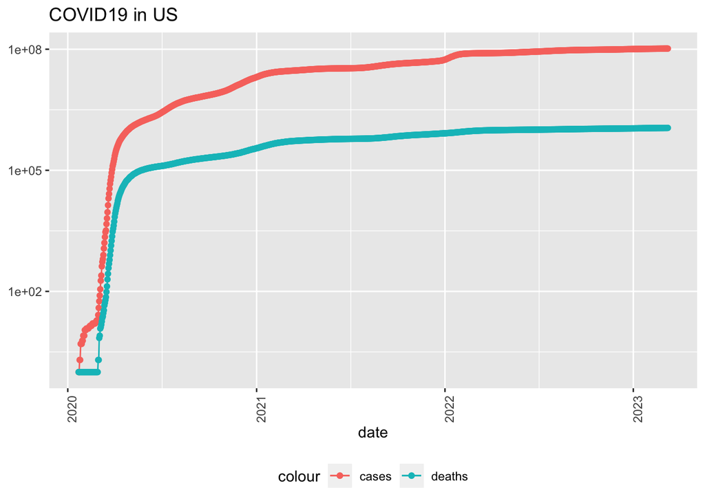

###US totals new cases

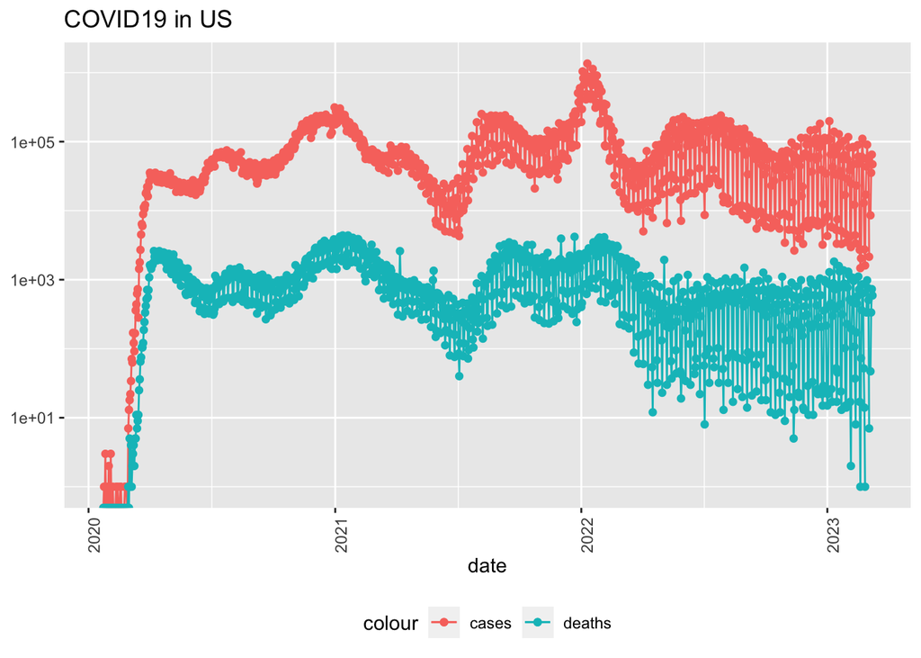

###US_by_state

```
## # A tibble: 66,294 × 7
##    Province_State Country_Region date       cases deaths deaths_per_mill
##    <chr>          <chr>          <date>     <dbl>  <dbl>           <dbl>
##  1 Alabama        US             2020-01-22     0      0               0
##  2 Alabama        US             2020-01-23     0      0               0
##  3 Alabama        US             2020-01-24     0      0               0
##  4 Alabama        US             2020-01-25     0      0               0
##  5 Alabama        US             2020-01-26     0      0               0
##  6 Alabama        US             2020-01-27     0      0               0
##  7 Alabama        US             2020-01-28     0      0               0
##  8 Alabama        US             2020-01-29     0      0               0
##  9 Alabama        US             2020-01-30     0      0               0
## 10 Alabama        US             2020-01-31     0      0               0
## # ℹ 66,284 more rows
## # ℹ 1 more variable: Population <dbl>
```

###Visualization of Illinois

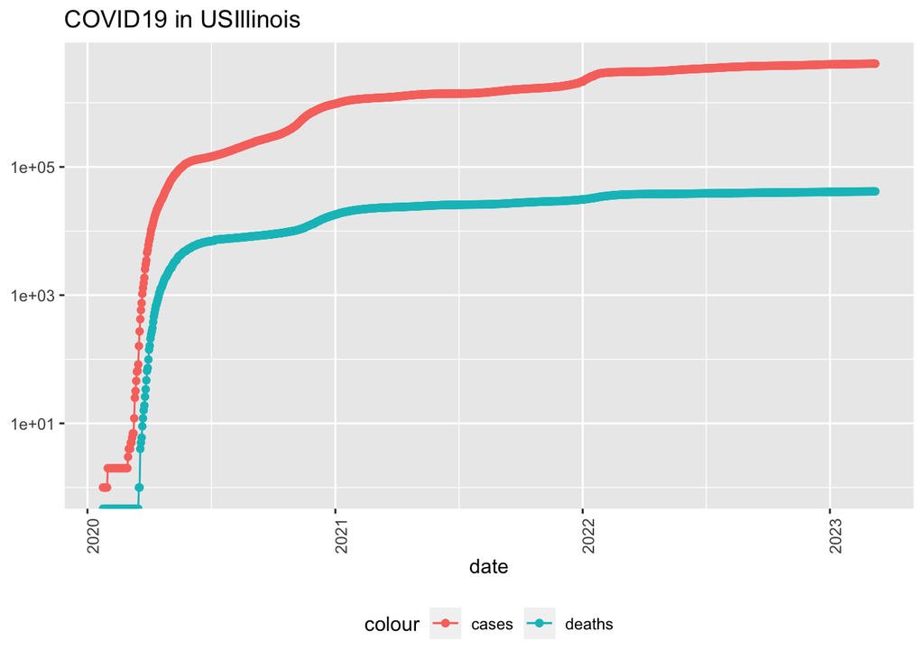

###New cases

```
## # A tibble: 66,294 × 9
##    Province_State Country_Region date       cases deaths deaths_per_mill
##    <chr>          <chr>          <date>     <dbl>  <dbl>           <dbl>
##  1 Alabama        US             2020-01-22     0      0               0
##  2 Alabama        US             2020-01-23     0      0               0
##  3 Alabama        US             2020-01-24     0      0               0
##  4 Alabama        US             2020-01-25     0      0               0
##  5 Alabama        US             2020-01-26     0      0               0
##  6 Alabama        US             2020-01-27     0      0               0
##  7 Alabama        US             2020-01-28     0      0               0
##  8 Alabama        US             2020-01-29     0      0               0
##  9 Alabama        US             2020-01-30     0      0               0
## 10 Alabama        US             2020-01-31     0      0               0
## # ℹ 66,284 more rows
## # ℹ 3 more variables: Population <dbl>, new_cases <dbl>, new_deaths <dbl>
```